# Soccer Analysis Using Statsbomb Data

Harvey Gonzalez, Alexi Umana, Samuel Nunez

04-20-2026

# **Introduction**

The data is sourced from StatsBomb’s Open Data repository via their R package. It contains highly detailed, event-level data for various soccer competitions, including every pass, shot, tackle, and defensive action recorded during matches. For this analysis, we are specifically filtering the data to look at UEFA Champions League matches.

- A link to the data repository [StatsBomb Open Data on GitHub](https://github.com/statsbomb/open-data)

**Limitations**: StatsBomb’s free tier only releases the Champions League Final from each season, rather than every match played. This means our analysis is based on a small sample of matches rather than a fuull season of games.

# **Questions**

**Main Question**: What factors influence winning in professional soccer matches?

- *Which players were caught in an offside position the most frequently?*
- *Does defensive maneuvers (tackles, pressures, interceptions, etc.) correlate with winning?*
- *Does playing at home provide a measurable advantage?*
- *What is the average score per match, and how are goals distributed between home and away teams?*
- *Where on the field do Champion League shots mostly originate from, and how does the score rate chance across different zones?*
- *How does shot quality (xG) drop as shot distance from goal increases?*
- *What are the score rates of penalty kicks?*

# **Key Terms for Unfiltered Data & Filtered Data**

- `player.name`: Name of the primary player involved in the event
- `type.name`: The primary category of the event (e.g., “Pass”, “Offside”, “Shot”, “Tackle”, “Pressure”)
- `team.name`: The team responsible for a given event
- `location`: A list with x and y coordinates (0-120 long, 0-80 wide) marking where the event occurred on the field
- `shot.outcome.name`: The result of a shot (e.g., “Goal”, “Saved”, “Off T”, “Post”)
- `shot.statsbomb_xg`: Expected goals — probability (0 to 1) that a shot becomes a goal based on location and context
- `shot.body_part.name`: The body part used for a shot (e.g., “Right Foot”, “Left Foot”)
- `shot.type.name`: Context of the shot (e.g., “Open Play”, “Penalty”, “Free Kick”)
- `home_score` / `away_score`: Final goals scored by the home and away teams
- `pass.outcome.name` / `pass.recipient.name`: Used to identify offside calls during passes

# **Key Values and Calculations:**

```r
#install.packages("devtools")
#install.packages("remotes")
#devtools::install_github("statsbomb/StatsBombR")
#install.packages("ggsoccer")


library(tidyverse)
library(dplyr)
library(ggsoccer)

# Required packages by StatsBombR
library(stringi)
library(rvest)
library(RCurl)
library(foreach)
library(iterators)
library(parallel)
library(httr)
library(jsonlite)
library(sp)

library(StatsBombR)
```

```r
# Load all free competitions
invisible(capture.output(
  Comp <- FreeCompetitions()
  ))

champLeagues_Comp <- Comp %>%
  filter(competition_name == "Champions League")

invisible(capture.output(
  Matches <- FreeMatches(champLeagues_Comp)
  ))

champLeagues_events <- list()

invisible(capture.output(
for (i in 1:nrow(Matches)) {
  match_data <- get.matchFree(Matches[i,])
  champLeagues_events[[i]] <- match_data
}
))

champLeagues_events <- bind_rows(champLeagues_events)
```

# **Most offside positions in the Champions League**

```
## # A tibble: 10 × 2
##    offside_player                 offside_count
##    <chr>                                  <int>
##  1 Roberto Boninsegna                         6
##  2 Fernando Morientes Sánchez                 5
##  3 Javier Hernández Balcázar                  5
##  4 Anderson Luís de Souza                     4
##  5 Dado Prso                                  4
##  6 Gabriel Omar Batistuta                     4
##  7 Djibril Cissé                              3
##  8 Filippo Inzaghi                            3
##  9 Francisco Román Alarcón Suárez             3
## 10 Hernán Jorge Crespo                        3
```

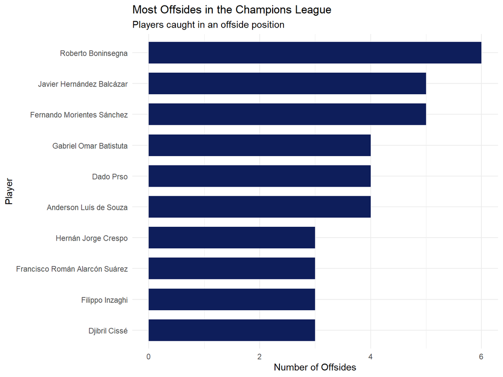

# **Average Goals per Match: Home vs. Away**

```
## [1] "Average total goals per match: 3"
```

```
## [1] "Average home team goals: 1.61"
```

```
## [1] "Average away team goals: 1.39"
```

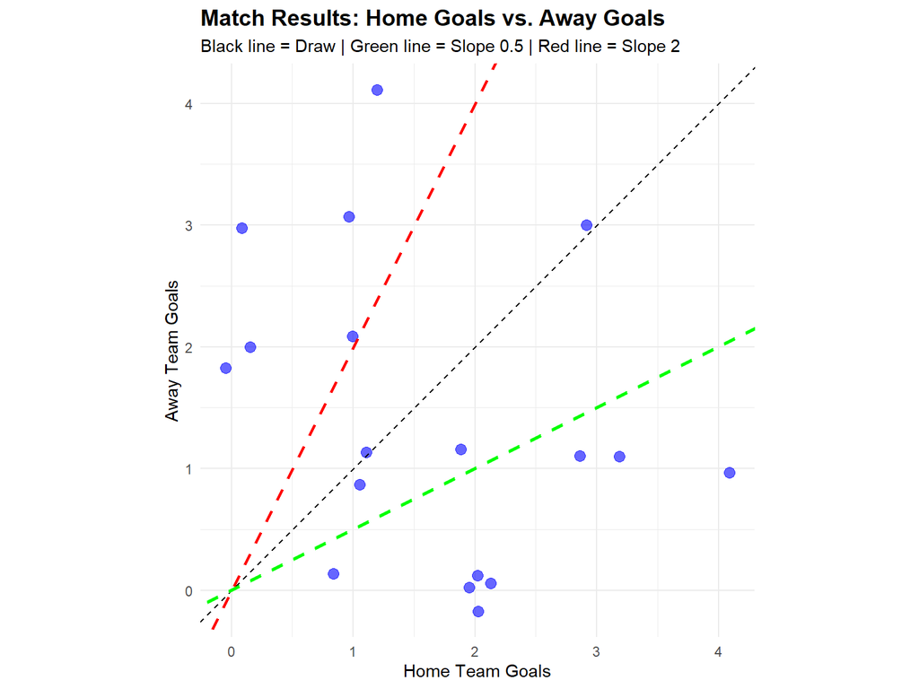

# **Does Defense Win More Games?**

#To determine if defense correlates with winning, we can measure the volume of defensive actions a team performs in a match (Tackles, Interceptions, Clearances, Blocks, and Pressures) and compare it to the match outcome.

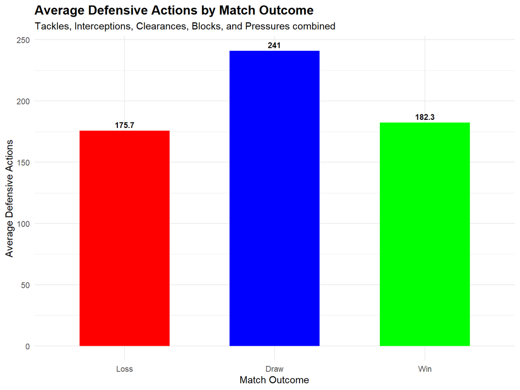

# **Does being on a home field gives an advantage?**

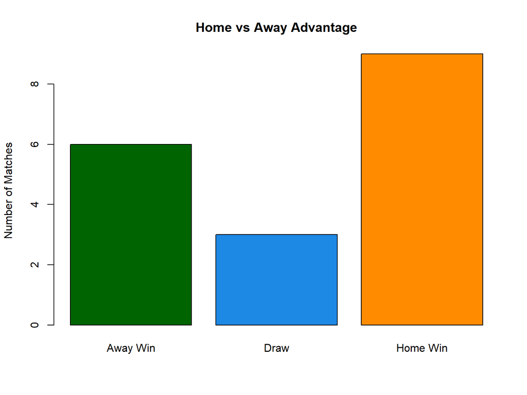

# **Does defense win more games?**

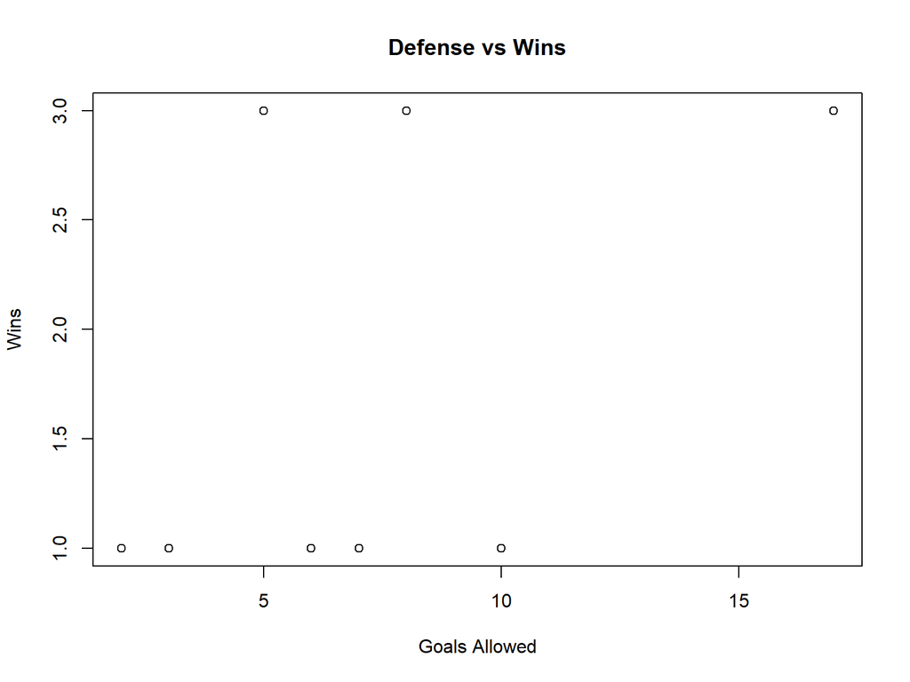

# **Whats the average score per match ?**

```r
# Step 2: Find the average

avg_g <- mean(ms$tg, na.rm = TRUE)
avg_g
```

```
## [1] 3
```

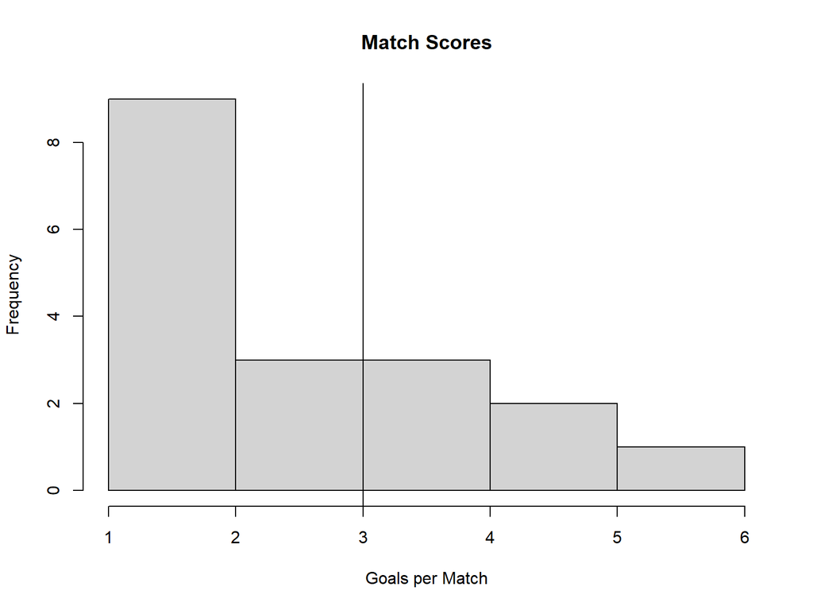

# **Penalty Shot Analysis**

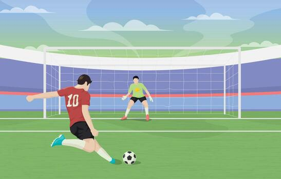

# **Penalty Shot Analysis Overview**

```
##   total_penalties Goals_Scored Off_Target Shots_Post Shots_Saved Scoring_Rate
## 1              33           23          1          2           7         69.7
```

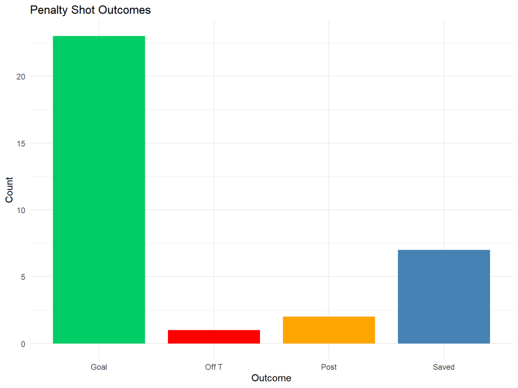

# **Penalty Shot Analysis - Body Part**

```
## # A tibble: 2 × 4
##   shot.body_part.name Total Goals Score_Rate
##   <chr>               <int> <int>      <dbl>
## 1 Right Foot             21    17         81
## 2 Left Foot              12     6         50
```

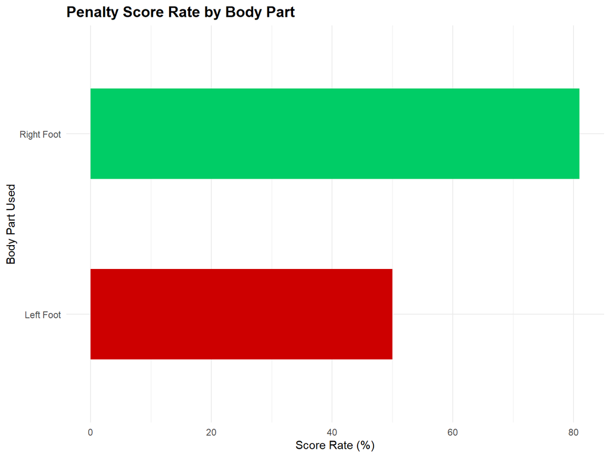

```
## # A tibble: 7 × 3
##   shot.body_part.name shot.outcome.name     n
##   <chr>               <chr>             <int>
## 1 Left Foot           Goal                  6
## 2 Left Foot           Off T                 1
## 3 Left Foot           Post                  1
## 4 Left Foot           Saved                 4
## 5 Right Foot          Goal                 17
## 6 Right Foot          Post                  1
## 7 Right Foot          Saved                 3
```

# **Shots On The Goal**

```
## # A tibble: 9 × 5
##   distance_band               lateral_zone total_shots goals score_rate
##   <chr>                       <chr>              <int> <int>      <dbl>
## 1 Edge of the Box (18-36 yds) Left Side             47     2        4.3
## 2 Edge of the Box (18-36 yds) Central              159     5        3.1
## 3 Edge of the Box (18-36 yds) Right Side            44     0        0
## 4 Inside the Box              Central              199    40       20.1
## 5 Inside the Box              Left Side             55     3        5.5
## 6 Inside the Box              Right Side            44     1        2.3
## 7 Long Range (36-48 yds)      Central                9     0        0
## 8 Long Range (36-48 yds)      Left Side              2     0        0
## 9 Very Long Range (48+ yds)   Central                1     0        0
```

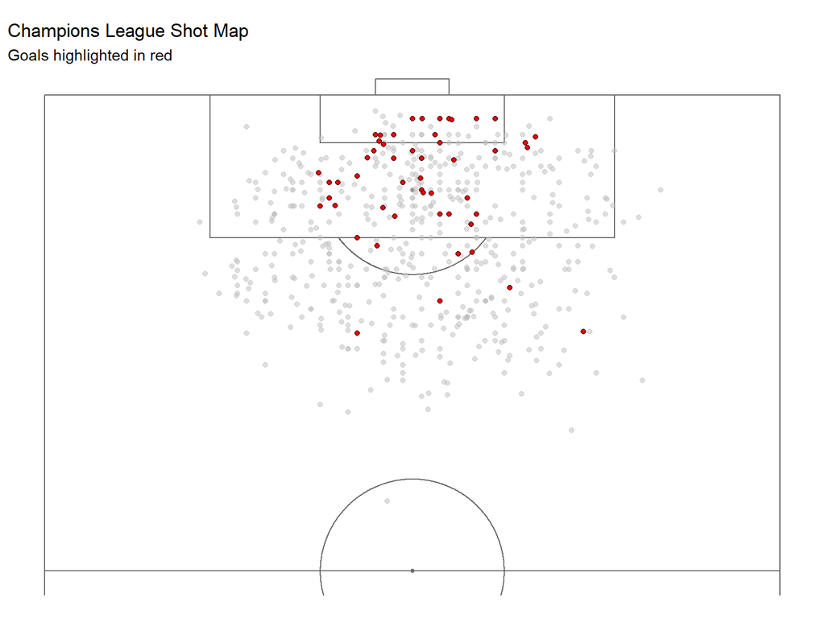

# **xG vs Shot Distance**

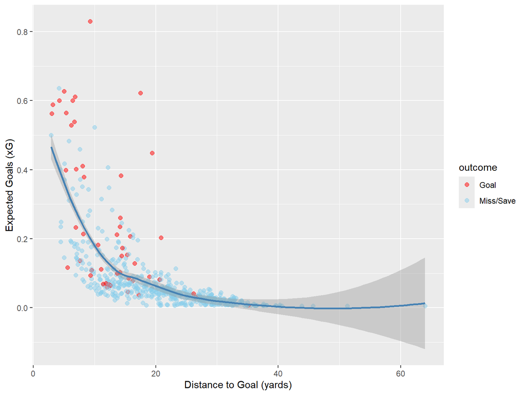

# Conclusion

So, what factors influence winning in professional soccer matches?

Shot location matters the most! Scoring rates increase drastically inside the box and in central zones, while xG drops steeply as distance from goal increases.

Home advantage is unclear. In our analysis, home teams win more often than away teams, but the gap is modest. However, our sample size is small and is not enough information to confidently conclude whether home-field advantage meaningfully influences winning in professional soccer.

Penalties are the single highest-probability scoring opportunity, which shows how important it is to draw fouls inside the box